# p8106_mtp

Abhishek Ajay

April 2, 2019

## Introduction

**Describe your data set. Provide proper motivation for your work.**

What questions are you trying to answer?

The following dataset has been obtained from the UCI Machine Learning Rpository. We are using the dataset that contains daily counts of bike rentals by both registered and casual members from the Capital Bikeshare System during the years 2011 and 2012. This dataset also contains weather data for each that’s been extracted from the www.freemeteo.com while it uses the dc.gov page to extract information about the binary holiday column.

Capital Bikeshare has over 350 stations in Washington, D.C., Alington, VA and MD, etc.

We are trying to use this dataset to see if temperature, weather and type of day (working day, weekend or a holiday) have any effect on the amount of bike rentals on any given day. Simply put, we’re trying to forecast bike rentals on any day. This can have a ton of implications in traffic management. Forecasting the amount of bikes on the road can give a better sense of travel time and allowing taxi services to provide more accurate “estimated time of arrival” estimates.

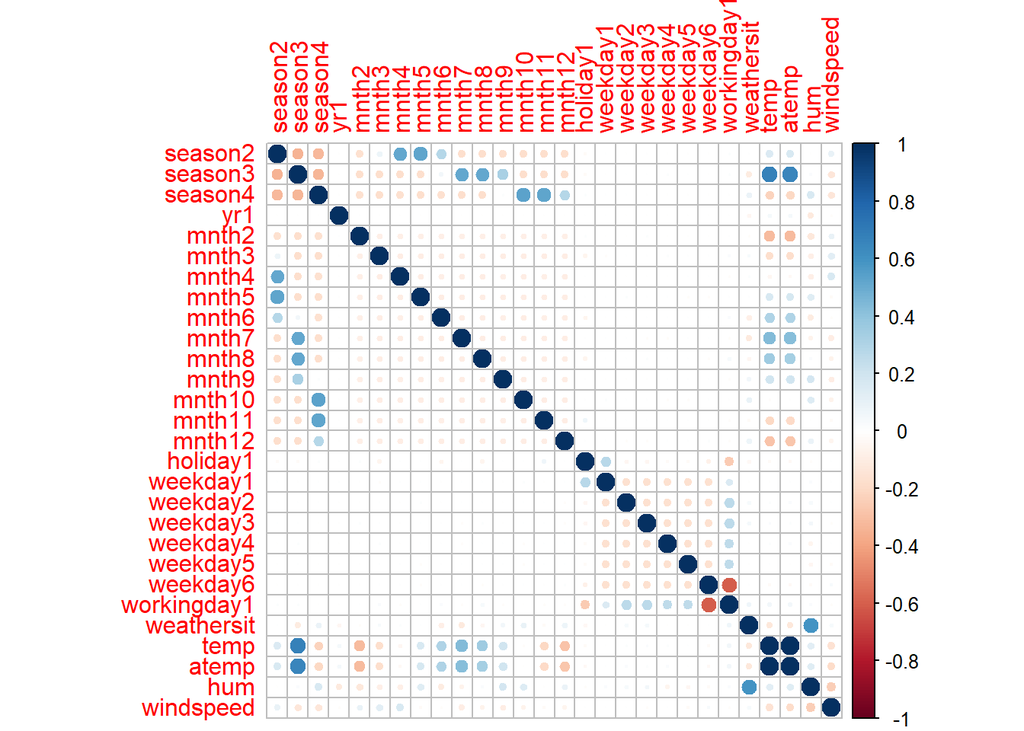

```r
day = read.csv("./data/day.csv") %>%
  janitor::clean_names() %>%
  select(-c(dteday, instant)) %>%
  mutate(season = as.factor(season),
         yr = as.factor(yr),
         mnth = as.factor(mnth),
         holiday = as.factor(holiday),
         weekday = as.factor(weekday),
         workingday = as.factor(workingday)
         #dteday = as.vector(dteday)
         )

x = day
x = model.matrix(casual + registered + cnt~., x)[,-1]
y = day$cnt
corrplot(cor(x))
```

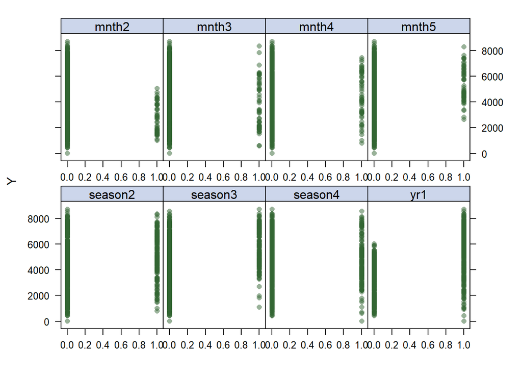

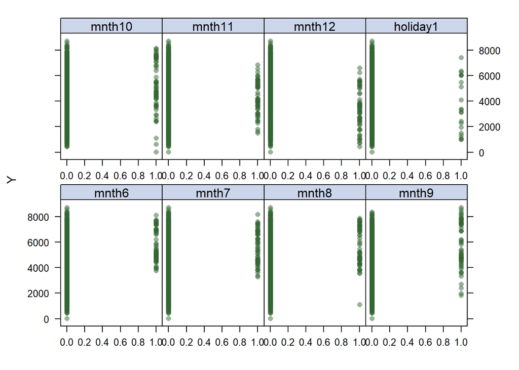

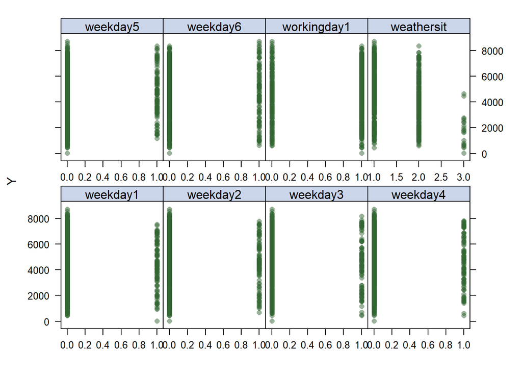

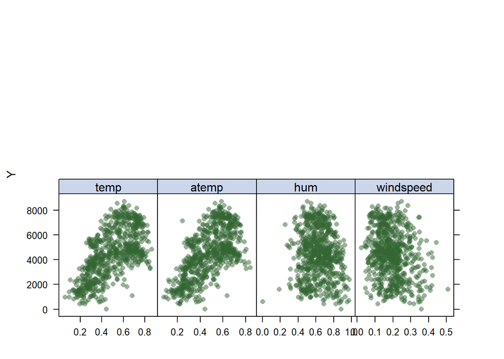

```r
#Non Linear Methods from L5.pdf
theme1 <-trellis.par.get()
theme1$plot.symbol$col <-rgb(.2, .4, .2, .5)
theme1$plot.symbol$pch <- 16
theme1$plot.line$col <-rgb(.8, .1, .1, 1)
theme1$plot.line$lwd <- 2
theme1$strip.background$col <-rgb(.0, .2, .6, .2)
trellis.par.set(theme1)
featurePlot(x, y, plot = "scatter", labels =c("","Y"),type =c("p"), layout =c(4, 2))
```

**How did you prepare and clean the data?**

```r
x_1 =
  day %>%
  select(-c( casual, registered, cnt))

x_1 = model.matrix(~., x_1)

ridge.mod <-glmnet(x_1, y, alpha=0, lambda =exp(seq(-1, 10, length=100)))
ridge.mod$lambda
```

```
##   [1] 2.202647e+04 1.971015e+04 1.763742e+04 1.578265e+04 1.412294e+04
##   [6] 1.263776e+04 1.130876e+04 1.011953e+04 9.055351e+03 8.103084e+03
##  [11] 7.250958e+03 6.488442e+03 5.806113e+03 5.195539e+03 4.649172e+03
##  [16] 4.160262e+03 3.722766e+03 3.331277e+03 2.980958e+03 2.667478e+03
##  [21] 2.386965e+03 2.135950e+03 1.911332e+03 1.710335e+03 1.530475e+03
##  [26] 1.369529e+03 1.225508e+03 1.096633e+03 9.813105e+02 8.781152e+02
##  [31] 7.857720e+02 7.031397e+02 6.291970e+02 5.630302e+02 5.038216e+02
##  [36] 4.508394e+02 4.034288e+02 3.610039e+02 3.230405e+02 2.890694e+02
##  [41] 2.586706e+02 2.314687e+02 2.071272e+02 1.853456e+02 1.658545e+02
##  [46] 1.484132e+02 1.328059e+02 1.188400e+02 1.063427e+02 9.515961e+01
##  [51] 8.515256e+01 7.619786e+01 6.818484e+01 6.101447e+01 5.459815e+01
##  [56] 4.885657e+01 4.371878e+01 3.912128e+01 3.500726e+01 3.132588e+01
##  [61] 2.803162e+01 2.508380e+01 2.244597e+01 2.008554e+01 1.797333e+01
##  [66] 1.608324e+01 1.439192e+01 1.287845e+01 1.152415e+01 1.031226e+01
##  [71] 9.227814e+00 8.257411e+00 7.389056e+00 6.612018e+00 5.916694e+00
##  [76] 5.294490e+00 4.737718e+00 4.239496e+00 3.793668e+00 3.394723e+00
##  [81] 3.037732e+00 2.718282e+00 2.432425e+00 2.176630e+00 1.947734e+00
##  [86] 1.742909e+00 1.559623e+00 1.395612e+00 1.248849e+00 1.117519e+00
##  [91] 1.000000e+00 8.948393e-01 8.007374e-01 7.165313e-01 6.411804e-01
##  [96] 5.737534e-01 5.134171e-01 4.594258e-01 4.111123e-01 3.678794e-01
```

```r
coef(ridge.mod)
```

```
## 30 x 100 sparse Matrix of class "dgCMatrix"
```

```
##    [[ suppressing 100 column names 's0', 's1', 's2' ... ]]
```

[output not shown]

[output cut: 627 more lines]

[output not shown]

we dropped the dteday because it does is a factor variable with too many levels and it basically is the same as the index which does not tells us anything in this test.

x_1: all independent variables y: cnt—the response

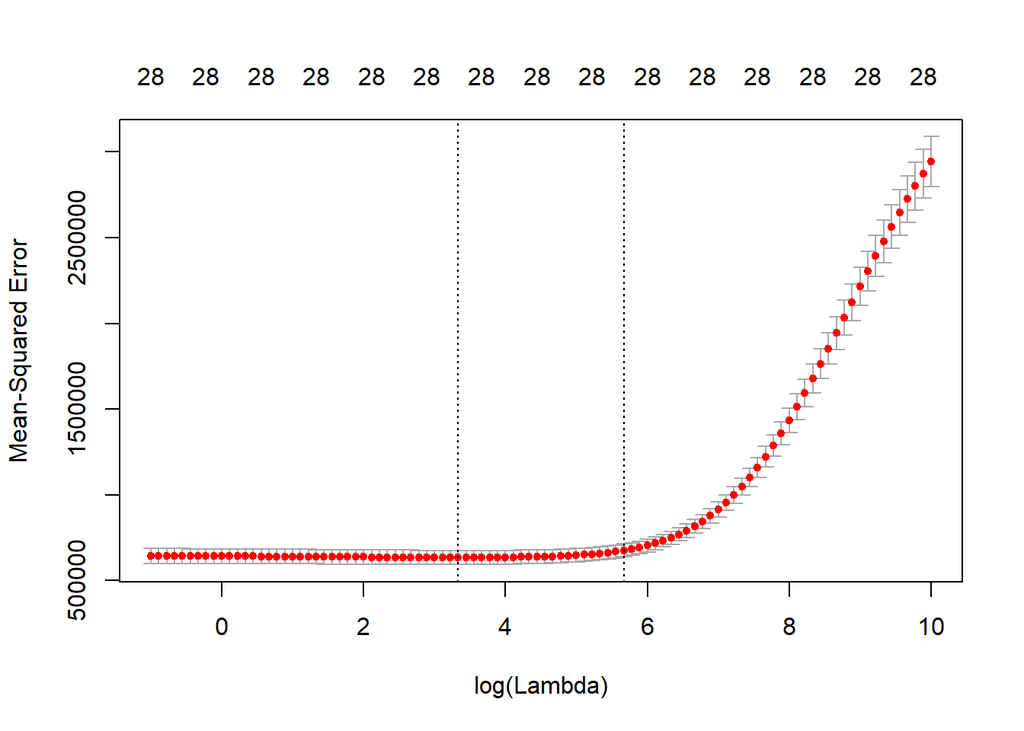

```r
set.seed(2)
cv.ridge <-cv.glmnet(x_1, y,alpha = 0,lambda =exp(seq(-1, 10, length=100)),type.measure = "mse")
plot(cv.ridge)
```

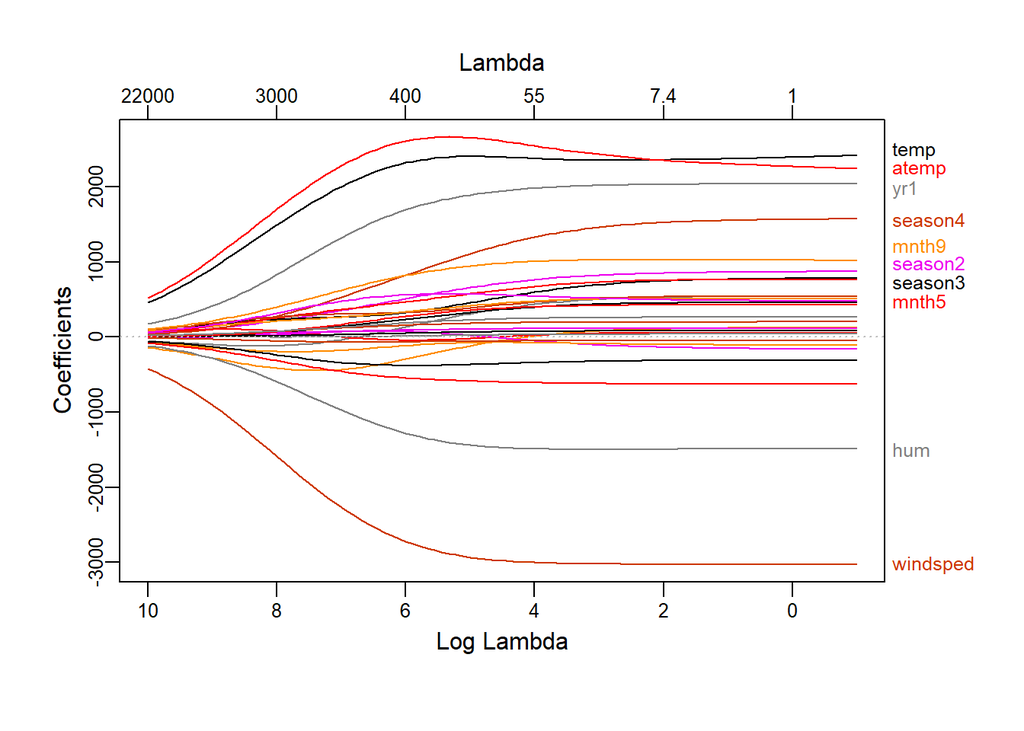

```r
plot_glmnet(ridge.mod, xvar = "rlambda")
```

```r
best.lambda = cv.ridge$lambda.min
best.lambda
```

```
## [1] 28.03162
```

```r
predict(ridge.mod, s = best.lambda, type="coefficients")
```

```
## 30 x 1 sparse Matrix of class "dgCMatrix"
##                       1
## (Intercept)  2194.33880
## (Intercept)     .
## season2       806.77376
## season3       669.10299
## season4      1425.28972
## yr1          2007.42196
## mnth2          62.85203
## mnth3         484.42234
## mnth4         427.00079
## mnth5         715.68689
## mnth6         501.39192
## mnth7          42.09289
## mnth8         497.96608
## mnth9        1021.60810
## mnth10        522.57642
## mnth11        -89.59238
## mnth12        -84.10455
## holiday1     -327.56920
## weekday1      -51.21017
## weekday2       35.44960
## weekday3       78.15475
## weekday4      114.64163
## weekday5      195.88355
## weekday6      414.34773
## workingday1   255.55538
## weathersit   -616.67433
## temp         2354.52018
## atemp        2464.43400
## hum         -1494.05323
## windspeed   -3015.37820
```

```r
cv.lasso <-cv.glmnet(x_1, y,alpha = 1,lambda =exp(seq(-1, 10, length=100)),type.measure = "mse")
cv.lasso$lambda.min
```

```
## [1] 1
```

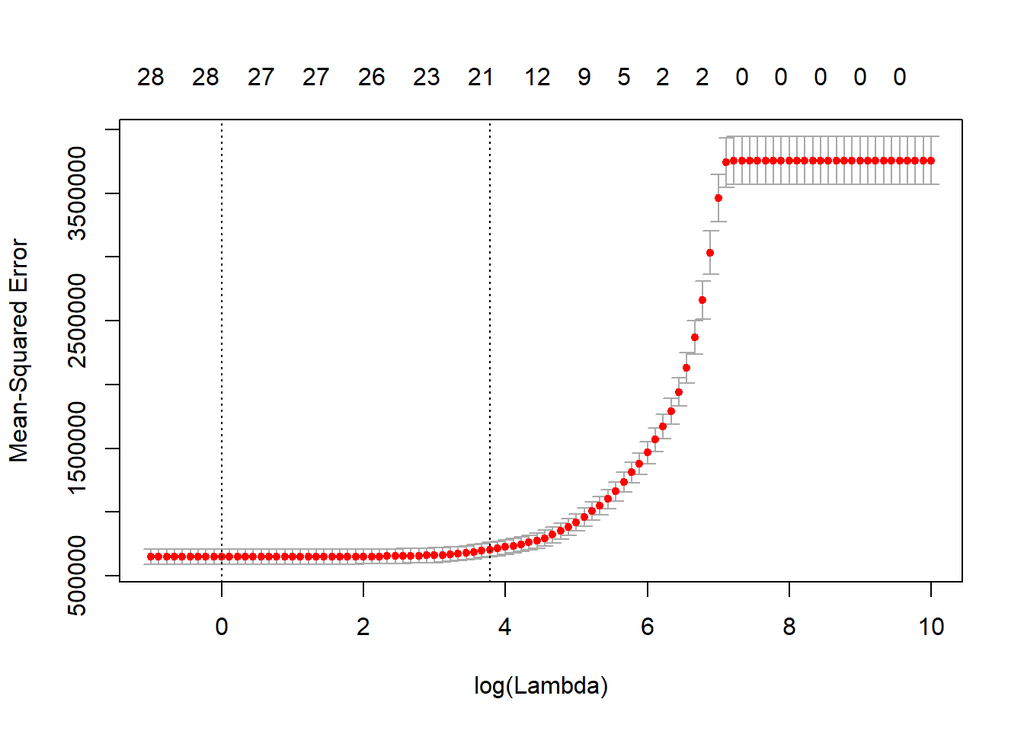

```r
plot(cv.lasso)
```

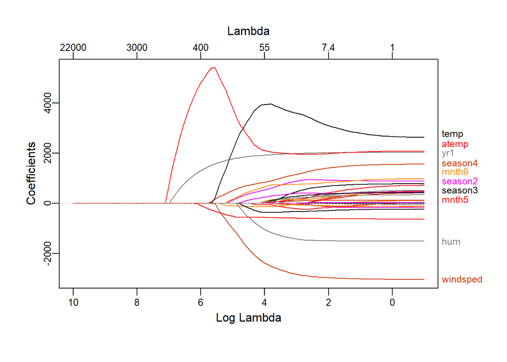

```r
plot_glmnet(cv.lasso$glmnet.fit)
```

```r
predict(cv.lasso, s="lambda.min", type="coefficients")
```

```
## 30 x 1 sparse Matrix of class "dgCMatrix"
##                         1
## (Intercept)  2176.2358199
## (Intercept)     .
## season2       885.5693453
## season3       775.1104442
## season4      1549.9064679
## yr1          2034.4519418
## mnth2          97.4033638
## mnth3         501.5496309
## mnth4         396.7099074
## mnth5         692.0047146
## mnth6         465.0276285
## mnth7          -9.2262346
## mnth8         441.4918821
## mnth9         969.1045928
## mnth10        449.6093953
## mnth11       -170.4564901
## mnth12       -121.0436175
## holiday1     -238.6709139
## weekday1     -125.8262950
## weekday2      -37.6624495
## weekday3        0.1702927
## weekday4       36.5475864
## weekday5      118.7331869
## weekday6      422.4047140
## workingday1   336.8633919
## weathersit   -624.2161072
## temp         2665.9789798
## atemp        2073.9923884
## hum         -1495.5614539
## windspeed   -3029.9000261
```

? why is that lasso best lambda is 1 ?

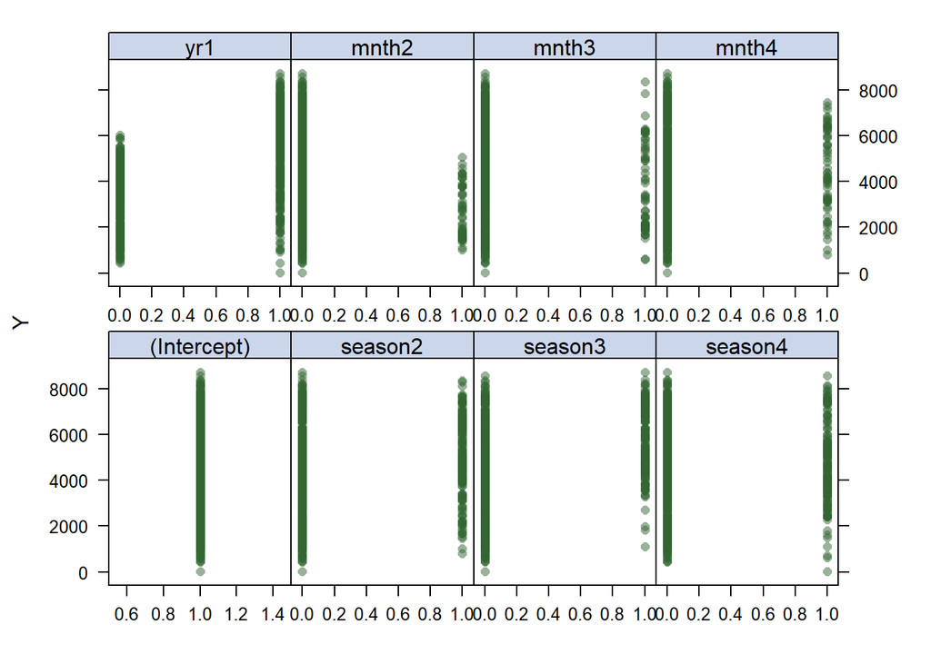

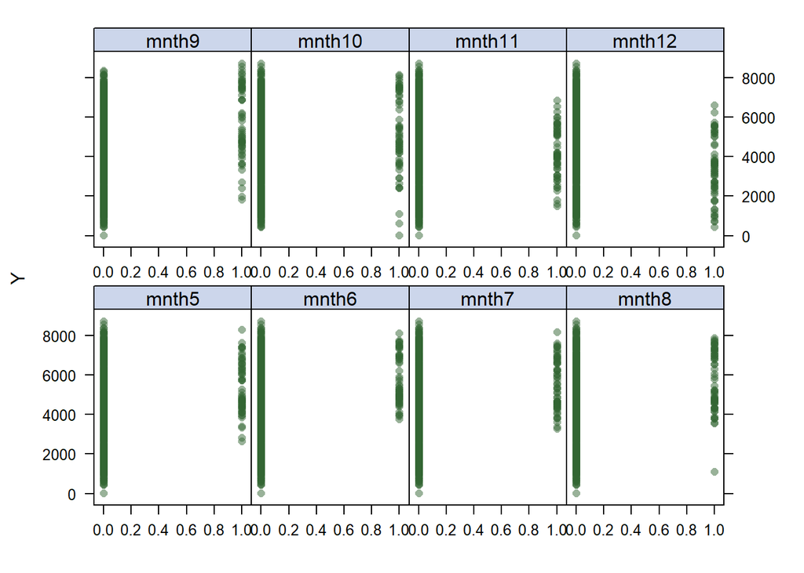

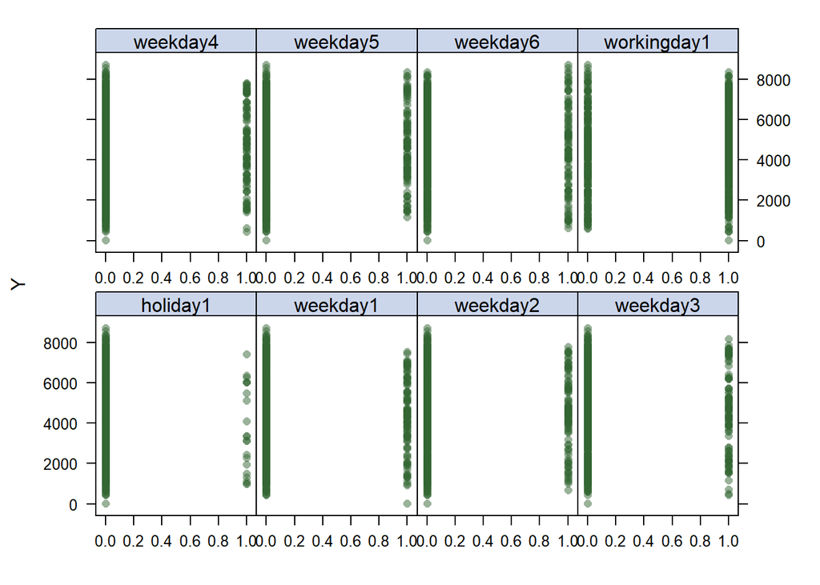

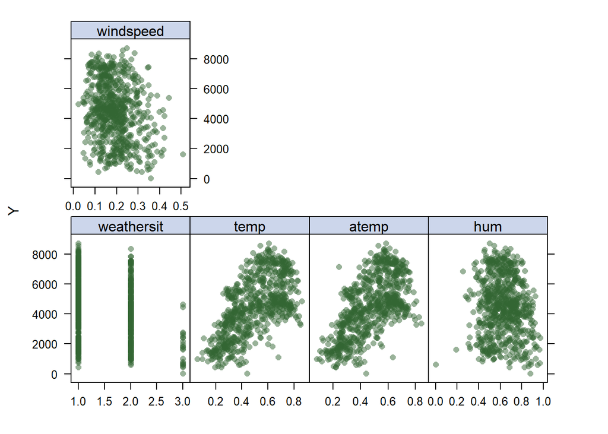

```r
theme1 <-trellis.par.get()
theme1$plot.symbol$col <-rgb(.2, .4, .2, .5)
theme1$plot.symbol$pch <- 16
theme1$plot.line$col <-rgb(.8, .1, .1, 1)
theme1$plot.line$lwd <- 2
theme1$strip.background$col <-rgb(.0, .2, .6, .2)
trellis.par.set(theme1)
featurePlot(x_1, y, plot = "scatter", labels =c("","Y"),type =c("p"), layout =c(4, 2))
```

actually this is pretty enough and straight forward to see some trends of these variables toward the bike usage.

smooth splines for temp

```r
fit.ss <-smooth.spline(day$temp, day$cnt)
fit.ss$df
```

```
## [1] 8.884527
```

```r
templims <-range(day$temp)
temp.grid <-seq(from = templims[1],to = templims[2], by = 0.0001)
length(temp.grid)
```

```
## [1] 8026
```

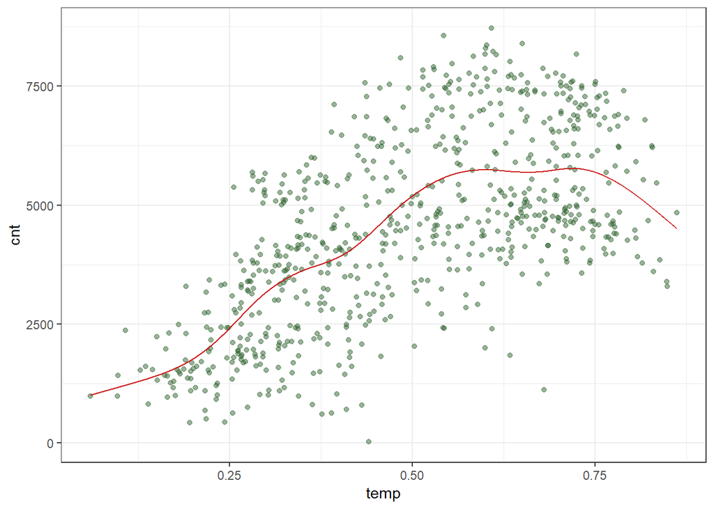

```r
pred.ss <-predict(fit.ss,
                  x = temp.grid)


pred.ss.df <-data.frame(pred = pred.ss$y,
                        temp = temp.grid)

p <-ggplot(data = day,aes(x = temp, y = cnt))+
  geom_point(color =rgb(.2, .4, .2, .5))

p+geom_line(aes(x = temp, y = pred), data = pred.ss.df,color =rgb(.8, .1, .1, 1))+ theme_bw()
```

humidity

```r
fit.ss <-smooth.spline(day$hum, day$cnt)
fit.ss$df
```

```
## [1] 4.529077
```

```r
humlims <-range(day$hum)
hum.grid <-seq(from = humlims[1],to = humlims[2], by = 0.001)
length(hum.grid)
```

```
## [1] 973
```

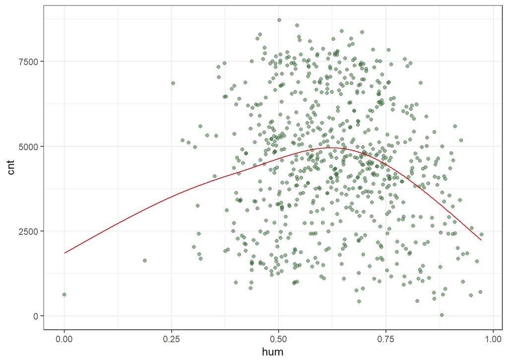

```r
pred.ss <-predict(fit.ss,
                  x = hum.grid)


pred.ss.df <-data.frame(pred = pred.ss$y,
                        hum = hum.grid)

p <-ggplot(data = day,aes(x = hum, y = cnt))+
  geom_point(color =rgb(.2, .4, .2, .5))

p+geom_line(aes(x = hum, y = pred), data = pred.ss.df,color =rgb(.8, .1, .1, 1))+ theme_bw()
```

pretty persuasive, since 0.5-0.75 is the best comfortable humidity

windspeed

```r
fit.ss <-smooth.spline(day$windspeed, day$cnt)
fit.ss$df
```

```
## [1] 6.012419
```

```r
windspeedlims <-range(day$windspeed)
windspeed.grid <-seq(from = windspeedlims[1],to = windspeedlims[2], by = 0.001)
length(windspeed.grid)
```

```
## [1] 486
```

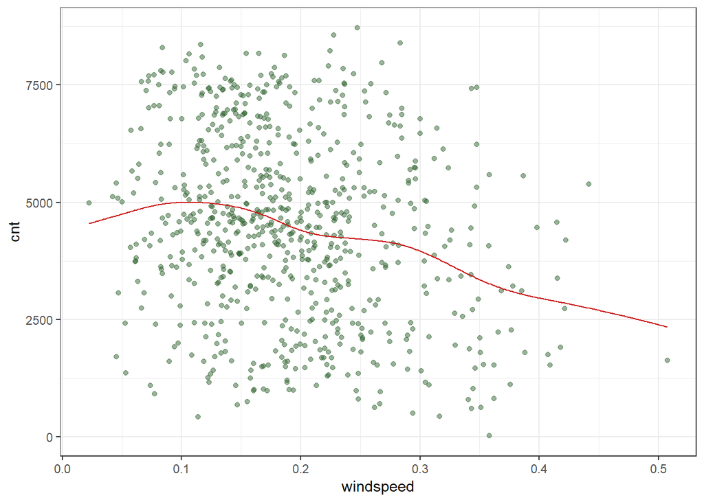

```r
pred.ss <-predict(fit.ss,
                  x = windspeed.grid)


pred.ss.df <-data.frame(pred = pred.ss$y,
                        windspeed = windspeed.grid)

p <-ggplot(data = day,aes(x = windspeed, y = cnt))+
  geom_point(color =rgb(.2, .4, .2, .5))

p+geom_line(aes(x = windspeed, y = pred), data = pred.ss.df,color =rgb(.8, .1, .1, 1))+ theme_bw()
```

windspeed ^ – cnt V

GAM

```r
gam.m1 = gam(cnt~ season + yr + mnth + holiday + weekday + workingday + weathersit + temp + atemp + hum + windspeed, data = day)


gam.m2 = gam(cnt~ season + yr + mnth + holiday + weekday + workingday + weathersit + s(temp) + atemp + hum + windspeed, data = day) # s:temp
gam.m3 = gam(cnt~ season + yr + mnth + holiday + weekday + workingday + weathersit + temp + s(atemp) + hum + windspeed, data = day) # s:atemp
gam.m4 = gam(cnt~ season + yr + mnth + holiday + weekday + workingday + weathersit + temp + atemp + s(hum) + windspeed, data = day) # s:hum
gam.m5 = gam(cnt~ season + yr + mnth + holiday + weekday + workingday + weathersit + temp + atemp + hum + s(windspeed), data = day) # s:windspeed

anova(gam.m1, gam.m2, test = "F")
```

```
## Analysis of Deviance Table
##
## Model 1: cnt ~ season + yr + mnth + holiday + weekday + workingday + weathersit +
##     temp + atemp + hum + windspeed
## Model 2: cnt ~ season + yr + mnth + holiday + weekday + workingday + weathersit +
##     s(temp) + atemp + hum + windspeed
##   Resid. Df Resid. Dev     Df  Deviance      F    Pr(>F)
## 1    703.00  430959946
## 2    695.93  326970947 7.0732 103988999 31.342 < 2.2e-16 ***
## ---
## Signif. codes:  0 '***' 0.001 '**' 0.01 '*' 0.05 '.' 0.1 ' ' 1
```

```r
anova(gam.m1, gam.m3, test = "F")
```

```
## Analysis of Deviance Table
##
## Model 1: cnt ~ season + yr + mnth + holiday + weekday + workingday + weathersit +
##     temp + atemp + hum + windspeed
## Model 2: cnt ~ season + yr + mnth + holiday + weekday + workingday + weathersit +
##     temp + s(atemp) + hum + windspeed
##   Resid. Df Resid. Dev     Df Deviance      F    Pr(>F)
## 1    703.00  430959946
## 2    697.54  339777843 5.4565 91182104 34.367 < 2.2e-16 ***
## ---
## Signif. codes:  0 '***' 0.001 '**' 0.01 '*' 0.05 '.' 0.1 ' ' 1
```

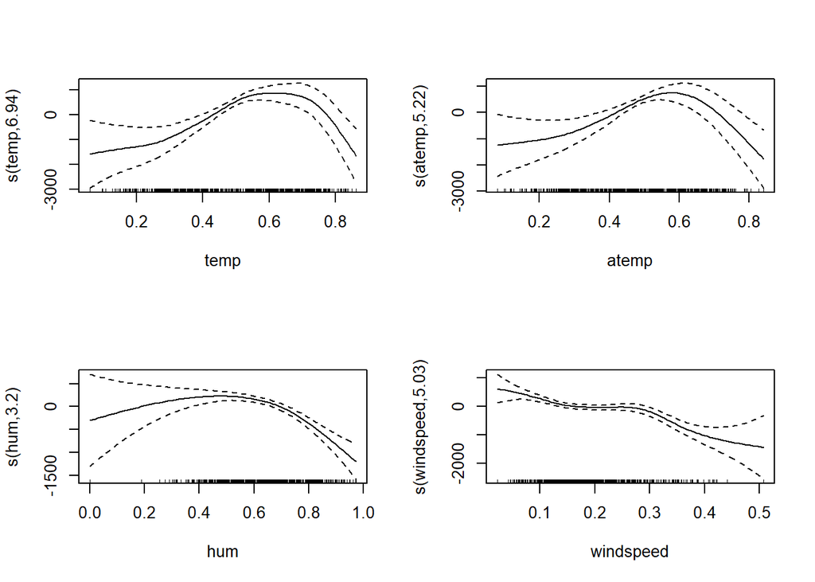

```r
par(mfrow=c(2,2))
plot(gam.m2)
plot(gam.m3)
plot(gam.m4)
plot(gam.m5)
```

```r
#deleting the yr and mnth variables

gam.m1 = gam(cnt~ season +  holiday + weekday + workingday + weathersit + temp + atemp + hum + windspeed, data = day)


gam.m2 = gam(cnt~ season +  holiday + weekday + workingday + weathersit + s(temp) + atemp + hum + windspeed, data = day) # s:temp
gam.m3 = gam(cnt~ season +  holiday + weekday + workingday + weathersit + temp + s(atemp) + hum + windspeed, data = day) # s:atemp
gam.m4 = gam(cnt~ season +  holiday + weekday + workingday + weathersit + temp + atemp + s(hum) + windspeed, data = day) # s:hum
gam.m5 = gam(cnt~ season +  holiday + weekday + workingday + weathersit + temp + atemp + hum + s(windspeed), data = day) # s:windspeed

anova(gam.m1, gam.m2, test = "F")
```

```
## Analysis of Deviance Table
##
## Model 1: cnt ~ season + holiday + weekday + workingday + weathersit +
##     temp + atemp + hum + windspeed
## Model 2: cnt ~ season + holiday + weekday + workingday + weathersit +
##     s(temp) + atemp + hum + windspeed
##   Resid. Df Resid. Dev     Df  Deviance      F    Pr(>F)
## 1    715.00 1226215499
## 2    708.85 1025089916 6.1457 201125583 22.669 < 2.2e-16 ***
## ---
## Signif. codes:  0 '***' 0.001 '**' 0.01 '*' 0.05 '.' 0.1 ' ' 1
```

```r
anova(gam.m1, gam.m3, test = "F")
```

```
## Analysis of Deviance Table
##
## Model 1: cnt ~ season + holiday + weekday + workingday + weathersit +
##     temp + atemp + hum + windspeed
## Model 2: cnt ~ season + holiday + weekday + workingday + weathersit +
##     temp + s(atemp) + hum + windspeed
##   Resid. Df Resid. Dev     Df  Deviance      F    Pr(>F)
## 1    715.00 1226215499
## 2    709.78 1041425397 5.2204 184790102 24.165 < 2.2e-16 ***
## ---
## Signif. codes:  0 '***' 0.001 '**' 0.01 '*' 0.05 '.' 0.1 ' ' 1
```

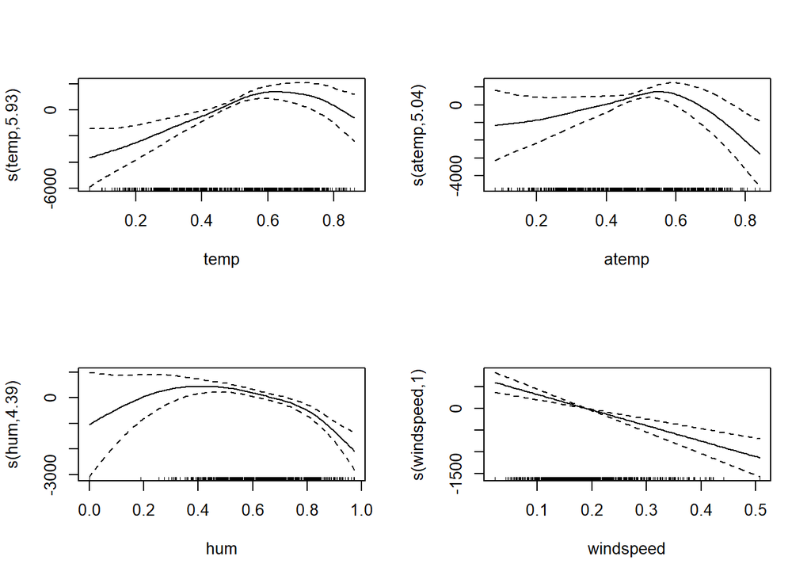

```r
par(mfrow=c(2,2))
plot(gam.m2)
plot(gam.m3)
plot(gam.m4)
plot(gam.m5)
```

```r
#GCV to select df

ctrl1 <-trainControl(method = "cv", number = 10)
set.seed(2)
gam.fit <-train(x_1, y,method = "gam",tuneGrid =data.frame(method = "GCV.Cp", select =c(TRUE,FALSE)),trControl = ctrl1)

gam.fit$bestTune
```

```
##   select method
## 2   TRUE GCV.Cp
```

```r
gam.fit$finalModel
```

```
##
## Family: gaussian
## Link function: identity
##
## Formula:
## .outcome ~ season2 + season3 + season4 + yr1 + mnth2 + mnth3 +
##     mnth4 + mnth5 + mnth6 + mnth7 + mnth8 + mnth9 + mnth10 +
##     mnth11 + mnth12 + weekday1 + weekday2 + weekday3 + weekday4 +
##     weekday5 + weekday6 + workingday1 + weathersit + s(temp) +
##     s(hum) + s(windspeed) + s(atemp)
##
## Estimated degrees of freedom:
## 6.57 3.41 4.83 0.00  total = 38.8
##
## GCV score: 447960
```

```r
x_2 =
  day %>%
  select(-c( casual, registered, cnt, yr, mnth))

x_2 = model.matrix(~., x_2)



set.seed(3)
gam.fit2 <-train(x_2, y,method = "gam",tuneGrid =data.frame(method = "GCV.Cp", select =c(TRUE,FALSE)),trControl = ctrl1)

gam.fit2$bestTune
```

```
##   select method
## 1  FALSE GCV.Cp
```

```r
gam.fit2$finalModel
```

```
##
## Family: gaussian
## Link function: identity
##
## Formula:
## .outcome ~ season2 + season3 + season4 + weekday1 + weekday2 +
##     weekday3 + weekday4 + weekday5 + weekday6 + workingday1 +
##     weathersit + s(temp) + s(hum) + s(windspeed) + s(atemp)
##
## Estimated degrees of freedom:
## 6.34 4.66 1.00 9.00  total = 33
##
## GCV score: 1407987
```

?The deviance is pretty huge of those ANOVA?

GCV score is too large.

```r
#poisson regression for categorical terms, exclude yr and mnth


day.glm1 <- glm(cnt~season + holiday + weekday + workingday + weathersit, family=poisson, data=day)
summary(day.glm1)
```

```
##
## Call:
## glm(formula = cnt ~ season + holiday + weekday + workingday +
##     weathersit, family = poisson, data = day)
##
## Deviance Residuals:
##    Min      1Q  Median      3Q     Max
## -78.74  -18.28   -3.11   15.92   90.47
##
## Coefficients: (1 not defined because of singularities)
##              Estimate Std. Error z value Pr(>|z|)
## (Intercept)  8.118121   0.002449 3315.40   <2e-16 ***
## season2      0.645786   0.001793  360.25   <2e-16 ***
## season3      0.744114   0.001756  423.85   <2e-16 ***
## season4      0.609837   0.001820  335.04   <2e-16 ***
## holiday1    -0.157663   0.003735  -42.22   <2e-16 ***
## weekday1     0.058507   0.002155   27.15   <2e-16 ***
## weekday2     0.083332   0.002098   39.73   <2e-16 ***
## weekday3     0.087709   0.002093   41.91   <2e-16 ***
## weekday4     0.104340   0.002079   50.18   <2e-16 ***
## weekday5     0.114533   0.002077   55.15   <2e-16 ***
## weekday6     0.088772   0.002086   42.56   <2e-16 ***
## workingday1        NA         NA      NA       NA
## weathersit  -0.235191   0.001093 -215.26   <2e-16 ***
## ---
## Signif. codes:  0 '***' 0.001 '**' 0.01 '*' 0.05 '.' 0.1 ' ' 1
##
## (Dispersion parameter for poisson family taken to be 1)
##
##     Null deviance: 668801  on 730  degrees of freedom
## Residual deviance: 382996  on 719  degrees of freedom
## AIC: 390418
##
## Number of Fisher Scoring iterations: 4
```

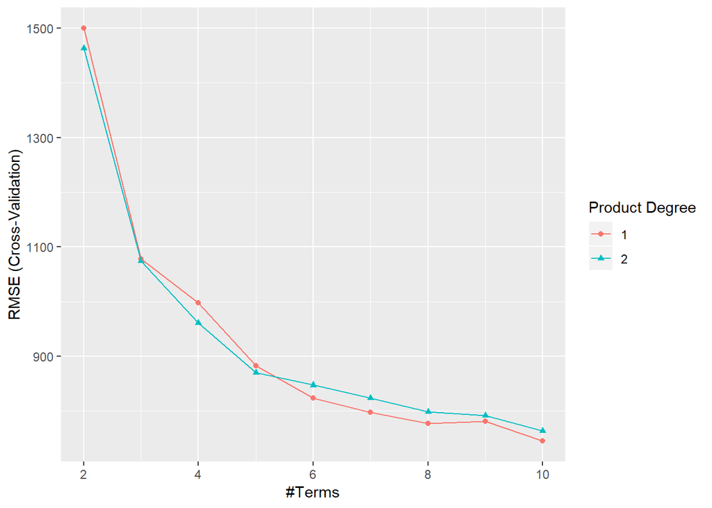

```r
#mars
mars_grid <-expand.grid(degree = 1:2,nprune = 2:10)
set.seed(2)
mars.fit <-train(x_1, y,method = "earth",tuneGrid = mars_grid,trControl = ctrl1)
ggplot(mars.fit)
```

```r
mars.fit$bestTune
```

```
##   nprune degree
## 9     10      1
```

```r
coef(mars.fit$finalModel)
```

```
##           (Intercept)     h(atemp-0.584608)                   yr1
##             1390.0991           -17182.5892             1955.9220
##       h(hum-0.622917)               season4 h(windspeed-0.296037)
##            -5284.9220             1331.0915            -9717.9681
##       h(weathersit-2)     h(atemp-0.249362)               season3
##            -1213.3876             9326.9665             1149.5032
##               season2
##              758.5902
```

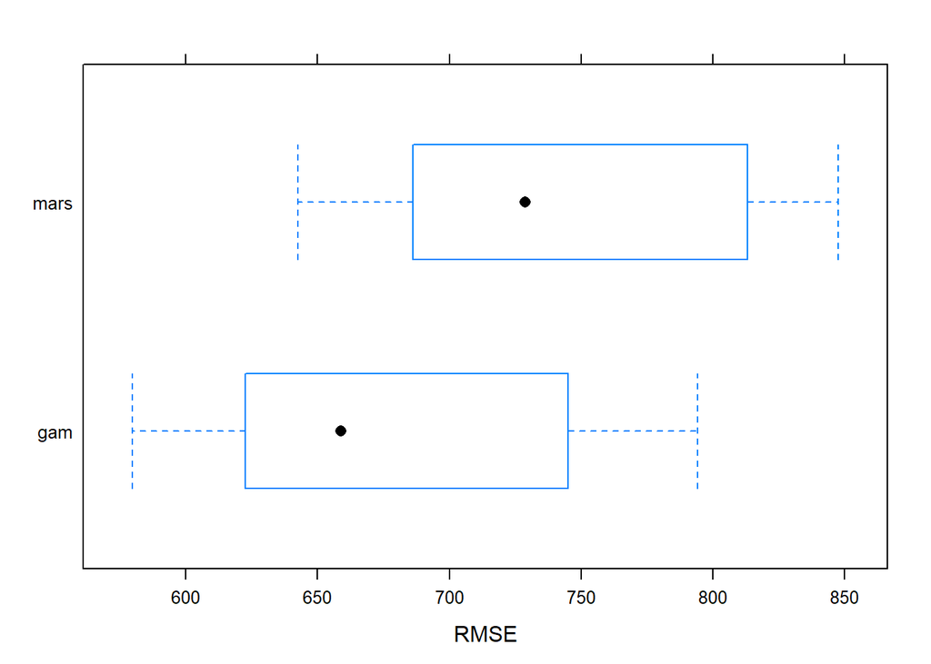

```r
bwplot(resamples(list(mars = mars.fit,gam = gam.fit)), metric = "RMSE")
```